# Coding exercise for ‘Exploration of AI Tools’

Yongjin Choi (LSHTM, Yongjin.Choi@lshtm.ac.uk)

2024-08-05

**Objectives**

The purpose of this exercise is to analyze the factors influencing vaccination and vaccine confidence using linear regression models in R. By fitting models, you will be able to:

- Identify Key predictors to determine the primary factors that significantly affect vaccination and vaccine confidence;
- Assess the impact of covariates; and
- Visualize the results by usnig summary tables and coefficient plots to clearly present the estimated coefficients and their confidence intervals. .

**To start**

In this exercise, you will create an R Markdown (RMD) file on your machine and replicate the code in this instruction. Follow these steps to set up your R Markdown notebook.

- Open RStudio.
- Click on `File` > `New File` > `R Markdown...`.
- Select `HTML` as the output format.
- Click `OK`
- General shortcuts
  - Run Current Chunk: `Ctrl + Alt + Enter` (Windows/Linux) or `Cmd + Option + C` (Mac)
  - Insert New Chunk: `Ctrl + Alt + I` (Windows/Linux) or `Cmd + Option + I` (Mac)

## Basic settings

### Description

This section loads the required packages.

### Loading Packages

Back to top

## Exercise 1: Regression

### Description

We will explore factors affecting the likelihood of receiving a COVID-19 vaccine and vaccine confidence using linear regression models in R.

**TRY YOUR BEST NOT TO LOOK INTO ‘SOLUTION’ PAGE BEFORE COMPLETING THE ‘Exercise’ PAGE.**

### Data preparation

We will re-use a subset of the Vaccine Confidence Index data. This dataset includes a deidentified sample of 4,368 respondents from nine countries. The data was collected during the COVID-19 pandemic. The survey included COVID-19 vaccination, vaccine confidence, and other variables that may influence people’s confidence in vaccines and decisions to get a vaccine. The codebook is avaiable at: [link](https://lshtm-my.sharepoint.com/:x:/g/personal/lshyc4_lshtm_ac_uk/EZZe-_n5VstMvhDoCanyxJoBRh5mi0GUWVVFtNoEWhQohg?e=Pv4m1l)

```r
# Load the dataset
fileloc <- "https://raw.githubusercontent.com/TheYongjinChoi/croucher-2024/69b8f398f5982c8364c6a25efe138ce2d6f31eb4/vci.csv"
df <- read.csv(fileloc)

# Creating variables
df <- df %>%
  mutate(vaxboost = ifelse(covidvax == 3, 1,
                           ifelse(covidvax <= 2, 0,
                                  ifelse(covidvax == 4, 0, NA))),
         trhcp_recode = ifelse(trhcp <= 2, 1, 0),
         female = ifelse(gender == 2, 1, 0),
         age = ifelse(age == 99, NA, age))

# trhcp_recode
# 0 Not much trust health care providers / Not at all
# 1 A lot / Somewhat trust health care providers

# Female
# 0 Other
# 1 Female

df$edu_recode <- car::recode(df$edu, "1:3=0; 4=1; 5:6=2; 7=0; 97:99=NA")
# 0 Secondary or lower / Vocational Post-Secondary
# 1 Tertiary
# 2 Master+

df$job_recode <- car::recode(df$job, "1:2=0; 3:5=4; 6=2; 7=4; 8=1; 9=3; 10=0; 11=4; 12:99=NA")
# 0 Employed
# 1 Students
# 2 Retired
# 3 Stay-at-home Parents
# 4 Unemployed/others
```

Back to top

### Exercise

We will examine the factors influencing the likelihood of receiving a COVID-19 vaccine (`vaxboost`) using linear regression models in R.

##### Fit the model

- Model 1 (`m1`): We want to examine the association between COVID-19 booster uptake `vaxboost` and trust in healthcare providers (`trhcp_recode`). Load the data `df`
- Model 2 (`m2`): Extend Model 1 by adding covariates, such as perceived risk of COVID-19 (`covidrisk`), having underlying conditions (`health`), gender (`female`), `age`, education level (`edu_recode`), and job status (`job_recode`)
- Model 3 (`m3`): Further extend Model 2 by including the country of residence (`cntry`) to have potential country-specific effects fixed

```r
# Fit the models
m1 <- lm(_____ ~ _____, data = _____)
m2 <- lm(_____ ~ _____ + _____ + _____ + _____ + factor(_____) + factor(_____) + factor(_____), data = _____)
m3 <- lm(_____ ~ _____ + _____ + _____ + _____ + factor(_____) + factor(_____) + factor(_____) + factor(_____), data = _____)
```

##### Create a summary table

- Use the `export_summs` function to create a summary table of the fitted models
- You can customize the labels of the covariates in the summary table for better readability

```r
# Creating a summary table
rtable <- _____(m1, m2, m3)

# Labeling
rtable$names[4] <- "Trust in HCPs"
rtable$names[6] <- "COVID risk perception"
rtable$names[8] <- "W/ Underlyig condition"
rtable$names[10] <- "Female"
rtable$names[12] <- "Age: 25-34"
rtable$names[14] <- "Age: 35-44"
rtable$names[16] <- "Age: 45-54"
rtable$names[18] <- "Age: 55+"
rtable$names[20] <- "Edu: Tertiary"
rtable$names[22] <- "Edu: Master+"
rtable$names[24] <- "Job: Students"
rtable$names[26] <- "Job: Retired"
rtable$names[28] <- "Job: Stay-at-home parents"
rtable$names[30] <- "Job: Unemployed/Other"

rtable
```

##### Create a coefficient plot

- Create a coefficient plot usign `plot_summs` to visualize the estimated coefficients and their confidence intervals across the three models.

```r
# Coefficient plot
fig <- _____(_____, _____, _____)
fig
```

Back to top

### Solution

We will examine the factors influencing the likelihood of receiving a COVID-19 vaccine (`vaxboost`) using linear regression models in R.

##### Fit the model

- Model 1 (`m1`): We want to examine the association between COVID-19 booster uptake `vaxboost` and trust in healthcare providers (`trhcp_recode`)
- Model 2 (`m2`): Extend Model 1 by adding covariates, such as perceived risk of COVID-19 (`covidrisk`), having underlying conditions (`health`), gender (`female`), `age`, education level (`edu_recode`), and job status (`job_recode`)
- Model 3 (`m3`): Further extend Model 2 by including the country of residence (`cntry`) to have potential country-specific effects fixed

```r
# Fit the models
m1 <- lm(vaxboost ~ trhcp_recode, data = df)
m2 <- lm(vaxboost ~ trhcp_recode + covidrisk + health + female + factor(age) + factor(edu_recode) + factor(job_recode), data = df)
m3 <- lm(vaxboost ~ trhcp_recode + covidrisk + health + female + factor(age) + factor(edu_recode) + factor(job_recode) + factor(cntry), data = df)
```

##### Create a summary table

- Use the `export_summs` function to create a summary table of the fitted models
- You can customize the labels of the covariates in the summary table for better readability

```r
# Creating a summary table
rtable <- export_summs(m1, m2, m3)

# Labeling
rtable$names[4] <- "Trust in HCPs"
rtable$names[6] <- "COVID risk perception"
rtable$names[8] <- "W/ Underlyig condition"
rtable$names[10] <- "Female"
rtable$names[12] <- "Age: 25-34"
rtable$names[14] <- "Age: 35-44"
rtable$names[16] <- "Age: 45-54"
rtable$names[18] <- "Age: 55+"
rtable$names[20] <- "Edu: Tertiary"
rtable$names[22] <- "Edu: Master+"
rtable$names[24] <- "Job: Students"
rtable$names[26] <- "Job: Retired"
rtable$names[28] <- "Job: Stay-at-home parents"
rtable$names[30] <- "Job: Unemployed/Other"

rtable
```

```
                                            ───────────────────────────────────────────────────────────────────────
                                                                            Model 1       Model 2       Model 3
                                                                        ───────────────────────────────────────────
                                              (Intercept)                    0.25 ***      0.18 ***      0.54 ***
                                                                            (0.02)        (0.03)        (0.04)
                                              Trust in HCPs                  0.31 ***      0.28 ***      0.18 ***
                                                                            (0.02)        (0.02)        (0.02)
                                              COVID risk perception                        0.00         -0.00
                                                                                          (0.00)        (0.00)
                                              W/ Underlyig condition                       0.00          0.00
                                                                                          (0.00)        (0.00)
                                              Female                                       0.01         -0.01
                                                                                          (0.02)        (0.01)
                                              Age: 25-34                                   0.05 *        0.05 *
                                                                                          (0.03)        (0.02)
                                              Age: 35-44                                   0.11 ***      0.12 ***
                                                                                          (0.03)        (0.02)
                                              Age: 45-54                                   0.14 ***      0.18 ***
                                                                                          (0.03)        (0.03)
                                              Age: 55+                                     0.27 ***      0.25 ***
                                                                                          (0.03)        (0.03)
                                              Edu: Tertiary                                0.02          0.05 **
                                                                                          (0.02)        (0.02)
                                              Edu: Master+                                -0.01          0.03
                                                                                          (0.04)        (0.04)
                                              Job: Students                               -0.13 ***     -0.02
                                                                                          (0.03)        (0.03)
                                              Job: Retired                                -0.07         -0.05
                                                                                          (0.04)        (0.04)
                                              Job: Stay-at-home parents                   -0.17 ***     -0.11 ***
                                                                                          (0.03)        (0.02)
                                              Job: Unemployed/Other                       -0.16 ***     -0.04
                                                                                          (0.03)        (0.02)
                                              factor(cntry)3                                            -0.08 **
                                                                                                        (0.03)
                                              factor(cntry)4                                            -0.30 ***
                                                                                                        (0.03)
```

[output cut: 19 more lines]

##### Create a coefficient plot

- Create a coefficient plot usign `plot_summs` to visualize the estimated coefficients and their confidence intervals across the three models.

```r
# Coefficient plot
fig <- plot_summs(m1, m2, m3)
```

[output not shown]

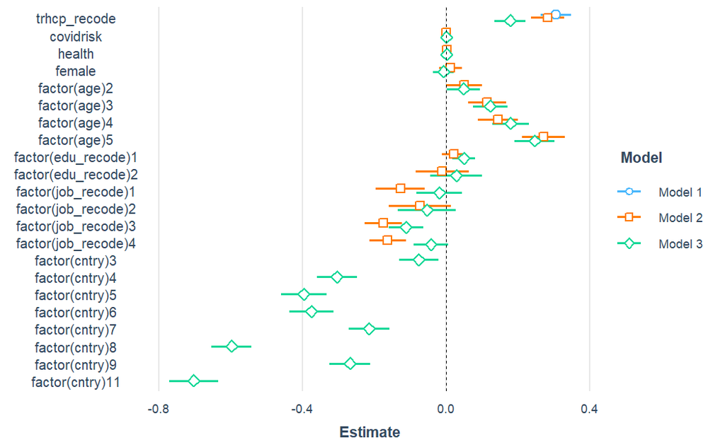

```r
fig
```

Back to top

## Exercise 2: Try your own analysis

### Description

To deepen your understanding and tailor the analysis to your interests, consider the following suggestions: * Test with additional variables: Explore other variables that might influence vaccination and vaccine confidence. For instance, you could include variables related to media use and the exposure to misinformation * Subset the data by country: Focus on specific countries to see if the associations hold or differ across different contexts. For example, you can subset the data by using this code. - 2 Cambodia - 3 Viet Nam - 4 Lao PDR - 5 Japan - 6 The Republic of Korea - 7 Malaysia - 8 Philippines - 9 Mongolia - 11 Papua New Guinea

```r
df.cambodia <- df %>% filter(cntry == 2)
df.japan <- df %>% filter(cntry == 5)
```

Back to top